# Vignette: Simulation of (weighted) trawl processes

Almut Veraart

2022-08-18

# Definition of a (weighted) trawl process

The `ambit` package can be used to simulate univariate (weighted) trawl processes of the form
$$Y_t =\int_{(-\infty,t]\times \mathbb{R}}
p(t-s)\mathbb{I}_{(0, a(t-s))}(x)L(dx,ds), \mbox{ for } t \ge 0.$$
We refer to $p$ as the weight/kernel function, $a$ as the trawl function and $L$ as the Lévy basis.

If the function $p$ is given by the identity function, $Y$ is a trawl process, otherwise we refer to $Y$ as a weighted trawl process.

## Choice of the trawl function

This package only considers the case when the trawl function, denoted by $a$, is strictly monotonically decreasing.

The following implementations are currently included in the function `sim_weighted_trawl`:

- Exponential trawl function (“Exp”): The trawl function is parametrised by one parameter $\lambda>0$ and defined as

$$a(x)=\exp(-\lambda x), \qquad
\mathrm{for \,} x \geq 0.$$

- supIG trawl function (“supIG”): The trawl function is parametrised by two parameters $\delta$ and $\gamma$, which are assumed to not be simultaneously equal to zero, and is defined as

$$a(x)=(1+2x\gamma^{-2})^{-1/2}\exp(\delta
\gamma(1-(1+2x\gamma^{-2})^{1/2})), \qquad \mathrm{for \,} x \geq
0.$$

- supGamma trawl function (“LM”): The trawl function is parametrised by two parameters $H> 1$ and $\alpha > 0$, and is defined as

$$a(x) = (1+x/\alpha)^{-H}, \qquad
\mathrm{for \,} x \geq 0.$$

Alternatively, the user can use the function `sim_weighted_trawl_gen` which requires specifying a monotonic trawl function $a(\cdot)$.

## Choice of kernel/weight

The user can choose a suitable weight function $p$. If no weight function is provided, then the function $p(x)=1$ for all $x$ is chosen. I.e. the resulting process is a trawl process rather than a weighted trawl process.

## Choice of Lévy bases

The driving noise of the process is given by a homogeneous Lévy basis denoted by $L$ with corresponding Lévy seed $L'$.

In the following, we denote by $A$ a Borel set with finite Lebesgue measure.

The following infinitely divisible distributions are currently included in the implementation:

### Support on $(0, \infty)$

- Gamma distribution (“Gamma”): $L'\sim \Gamma(\alpha_g, \sigma_g)$, where $\alpha_g>0$ is the shape parameter and $\sigma_g>0$ the scale parameter. Then the corresponding density is given by
  $$f(x)=\frac{1}{\sigma_g^{\alpha_g}\Gamma(\alpha_{g})}x^{\alpha_g-1}e^{-x/\sigma_g},$$
  for $x>0$. The characteristic function is given by
  $$\psi(u)=(1-ui\sigma_g)^{\alpha_g},$$
  for $u\in \mathbb{R}$. We note that $\mathbb{E}(L')=\alpha_g \sigma_g$, $\mathrm{Var}(L')=\alpha_g \sigma_g^2$ and $c_4(L')=6\alpha \sigma^4$. Here we have
  $$L(A)\sim \Gamma(\mathrm{Leb}(A)\alpha_g, \sigma_g).$$

### Support on $\mathbb{R}$

- Gaussian case (“Gaussian”): $L'\sim \mathrm{N}(\mu, \sigma^2)$. In this case,
  $$L(A)\sim \mathrm{N}(\mathrm{Leb}(A)\mu, \mathrm{Leb}(A)\sigma^2).$$
  We note that $\mathbb{E}(L')=\mu$, $\mathrm{Var}(L')=\sigma^2$ and $c_4(L')=0$.
- Cauchy distribution (“Cauchy”): $L'\sim \mathrm{Cauchy}(l, s)$, where $l\in \mathbb{R}$ is the location parameter and $s>0$ the scale parameter. The corresponding density is given by
  $$f(x)=\frac{1}{\pi s(1+(x-l)/s)^2}, \quad x \in \mathbb{R},$$
  and the characteristic function is given by
  $$\psi(u)=l i u-s|u|, \quad u \in \mathbb{R}.$$
  Here we have
  $$L(A) \sim \mathrm{Cauchy}(l\mathrm{Leb}(A), s\mathrm{Leb}(A)).$$
- Normal inverse Gaussian case (“NIG”): $L'\sim \mathrm{NIG}(\mu, \alpha, \beta, \delta)$, where $\mu \in \mathbb{R}$ is the location parameter, $\alpha \in \mathbb{R}$ the tail heaviness parameter, $\beta \in \mathbb{R}$ the asymmetry parameter and $\delta\in \mathbb{R}$ the scale parameter. We set $\gamma=\sqrt{\alpha^2-\beta^2}$. The corresponding density is given by
  $$f(x)=\frac{\alpha \delta
  K_1(\alpha\sqrt{\delta^2+(x-\mu)^2})}{\pi\sqrt{\delta^2+(x-\mu)^2}}
  \exp(\delta \gamma+\beta(x-\mu)), \quad x \in \mathbb{R}.$$
  Here $K_1$ denotes the Bessel function of the third kind with index 1. The characteristic function is given by
  $$\psi(u)=\exp(iu\mu+\delta(\gamma-\sqrt{\alpha^2-(\beta+iu)^2})), \quad u
  \in \mathbb{R}.$$
  In this case, we have
  $$L(A)\sim \mathrm{NIG}(\mu \mathrm{Leb}(A), \alpha, \beta, \delta
  \mathrm{Leb}(A)).$$
  Also, $\mathbb{E}(L')=\mu +\frac{\delta \beta}{\gamma}$, $\mathrm{Var}(L')=\frac{\delta \alpha^2}{\gamma^3}$ and $c_4(L')=\frac{3\alpha^2\delta(4\beta^2+\alpha^2)}{\gamma^7}$.

### Support on $\mathbb{N}_0=\{0, 1, \ldots\}$

- Poisson case (“Poisson”): $L' \sim \mathrm{Poi}(v)$ for $v > 0$. In this case,
  $$L(A)\sim \mathrm{Poi}(\mathrm{Leb}(A)v).$$
  We note that $\mathbb{E}(L')=\lambda$, $\mathrm{Var}(L')=\lambda$ and $c_4(L')=\lambda$.
- Negative binomial case (“NegBin”): $L'\sim \mathrm{NegBin}(m, \theta)$ for $m>0, \theta \in (0, 1)$. I.e. the corresponding probability mass function is given by $\mathrm{P}(L'=x)=\frac{1}{x!}\frac{\Gamma \left( m +x\right) }{\Gamma \left( m \right) }\left( 1-\theta \right)^{m }\theta^{x}$ for $x \in \{0, 1, \ldots\}$. We note that $\mathbb{E}(L')=m \theta/(1-\theta)$, $\mathrm{Var}(L')=m \theta/(1-\theta)^2$ and $c_4(L')=m\theta(\theta^2+4\theta+1)/(\theta-1)^4$. Then,

$$L(A)\sim \mathrm{NegBin}(\mathrm{Leb}(A)m, \theta).$$

### Examples

We demonstrate the simulation of various trawl processes.

```r
library(ambit)
library(ggplot2)
```

We start off with a trawl with standard normal marginal distribution and exponential trawl function.

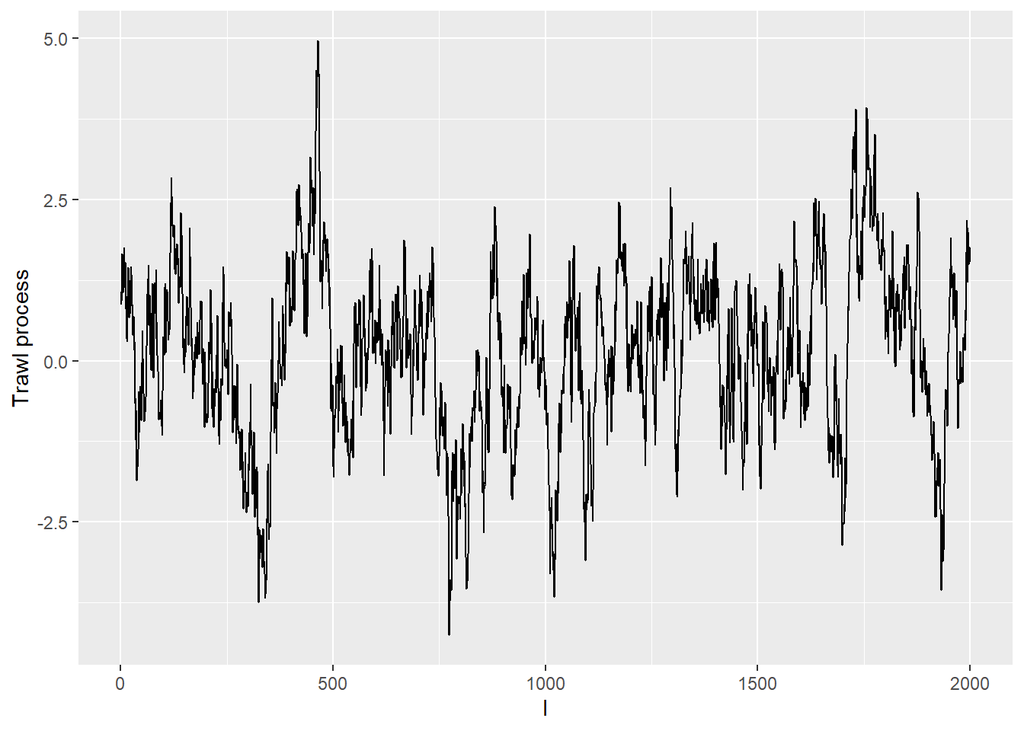

```r
#Set the number of observations
n <-2000
#Set the width of the grid
Delta<-0.1

#Determine the trawl function
trawlfct="Exp"
trawlfct_par <-0.5

#Choose the marginal distribution
distr<-"Gauss"
#mean 0, std 1
distr_par<-c(0,1)

#Simulate the path
set.seed(233)
path <- sim_weighted_trawl(n, Delta, trawlfct, trawlfct_par, distr, distr_par)$path

#Plot the path
df <- data.frame(time = seq(0,n,1), value=path)
p <- ggplot(df, aes(x=time, y=path))+
    geom_line()+
    xlab("l")+
    ylab("Trawl process")
p
```

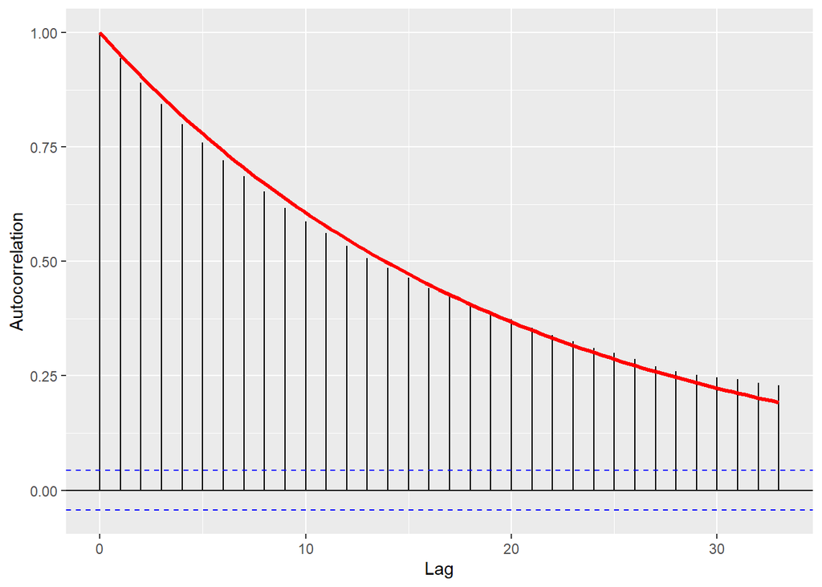

```r
#Plot the empirical acf and superimpose the theoretical one

#Plot the acf
my_acf <- acf(path, plot = FALSE)
my_acfdf <- with(my_acf, data.frame(lag, acf))
#Confidence limits
alpha <- 0.95
conf.lims <- c(-1,1)*qnorm((1 + alpha)/2)/sqrt(n)
q <- ggplot(data = my_acfdf, mapping = aes(x = lag, y = acf)) +
       geom_hline(aes(yintercept = 0)) +
       geom_segment(mapping = aes(xend = lag, yend = 0))+
        geom_hline(yintercept=conf.lims, lty=2, col='blue') +
        geom_function(fun = function(x) acf_Exp(x*Delta,trawlfct_par), colour="red", size=1.2)+
        xlab("Lag")+
        ylab("Autocorrelation")
q
```

The same trawl process can be obtained using the `sim_weighted_trawl_gen` instead as follows:

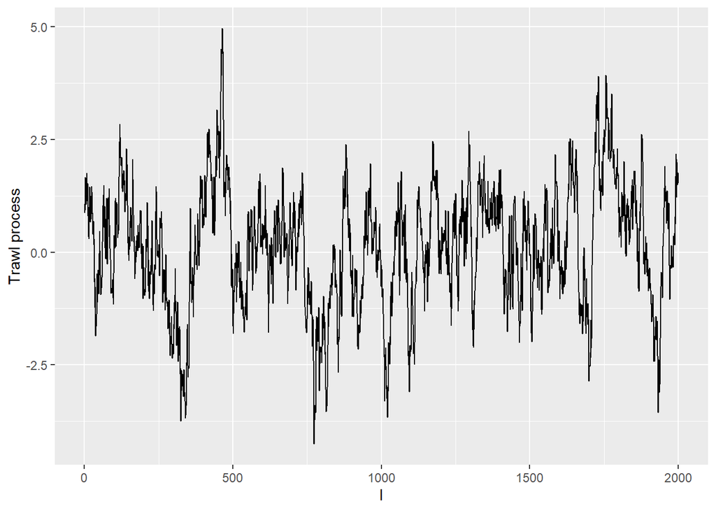

```r
#Set the number of observations
n <-2000
#Set the width of the grid
Delta<-0.1

#Determine the trawl function
trawlfct_par <-0.5
a <- function(x){exp(-trawlfct_par*x)}

#Choose the marginal distribution
distr<-"Gauss"
#mean 0, std 1
distr_par<-c(0,1)

#Simulate the path
set.seed(233)
path <- sim_weighted_trawl_gen(n, Delta, trawlfct_gen=a, distr, distr_par)$path

#Plot the path
df <- data.frame(time = seq(0,n,1), value=path)
p <- ggplot(df, aes(x=time, y=path))+
    geom_line()+
    xlab("l")+
    ylab("Trawl process")
p
```

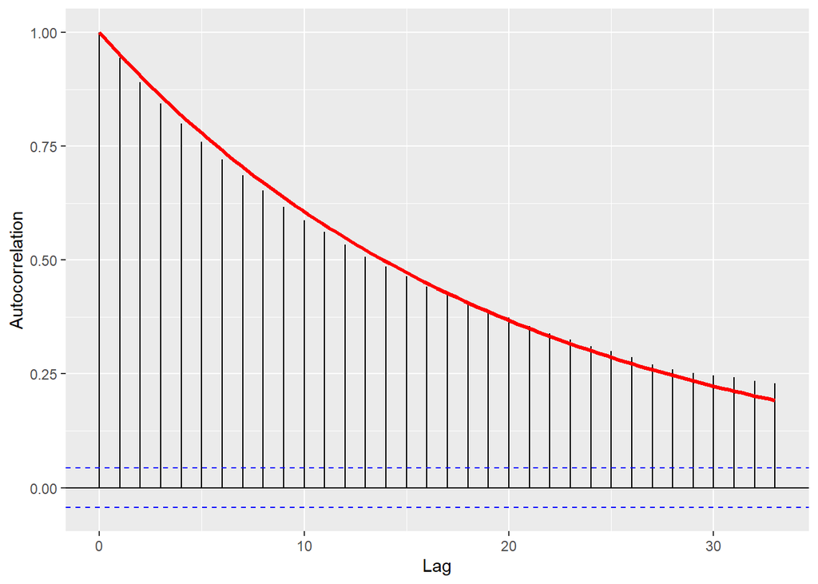

```r
#Plot the empirical acf and superimpose the theoretical one

#Plot the acf
my_acf <- acf(path, plot = FALSE)
my_acfdf <- with(my_acf, data.frame(lag, acf))
#Confidence limits
alpha <- 0.95
conf.lims <- c(-1,1)*qnorm((1 + alpha)/2)/sqrt(n)
q <- ggplot(data = my_acfdf, mapping = aes(x = lag, y = acf)) +
       geom_hline(aes(yintercept = 0)) +
       geom_segment(mapping = aes(xend = lag, yend = 0))+
        geom_hline(yintercept=conf.lims, lty=2, col='blue') +
        geom_function(fun = function(x) acf_Exp(x*Delta,trawlfct_par), colour="red", size=1.2)+
        xlab("Lag")+
        ylab("Autocorrelation")
q
```